# Projekt 1

Wiktoria Skowron

08-01-2022

**ZADANIE 1.**  
Wybrane zadania z zajęć ćwiczeniowych:

*Zadanie 1.* Stworzyć funkcję, która na podstawie długości boków trójkąta odpowiada na pytanie o to, czy trójkąt jest ostrokątny, prostokątny lub rozwartokątny.  
Stworzona funkcja na początku pobiera argumenty, które są długościami trzech boków wybranego trójkąta. Następnie sprawdza, czy z danych boków można zbudować trójkąt (*suma długości dwóch najkrótszych boków musi być większa od długości najdłuższego boku trójkąta*) oraz określa, czy trójkąt jest prostokątny (*tw. Pitagorasa*), rozwartokątny czy ostrokątny.

```r
#funkcja sprawdzająca odpowiednie warunki za pomocą konstrukcji if, else if, else

trojkat<-function(a,b,c)
  {if((a+b>c)&&(a+c>b)&&(b+c>a)) #sprawdzenie czy z danych bokow moze byc troj
  {
    if(a^2>b^2+c^2||b^2>a^2+c^2||c^2>b^2+a^2)
    {return("rozwartokatny")}

    else if(a^2<b^2+c^2&&b^2<a^2+c^2&&c^2<b^2+a^2)
    {return("ostrokatny")}

    else{return("prostokatny")}
  }
  else {print("Nie mozna zbudowac trojkata!")}
}
#test1
trojkat(3,4,5)
```

```
## [1] "prostokatny"
```

```r
#test2
trojkat(4,5,6)
```

```
## [1] "ostrokatny"
```

```r
#test3
trojkat(5,7,9)
```

```
## [1] "rozwartokatny"
```

*Zadanie 2.* W pakiecie datasets znajduje sie wiele ciekawych zbiorów danych, a w szczegolności ramki danych mtcars i Orange.  
a) Wykorzystaj komendy str() oraz help(), by dowiedzieć się więcej o tych zbiorach danych. Napisz w kilku słowach, co opisują w/w pliki z danymi.  
Zbiór danych “mtcars” opisuje paramentry 32 aut takie jak na przykład liczba cylindrów, spalanie, waga auta czy liczba koni mechanicznych.  
Zbiór danych “Orange” opisuje dane odnośnie wzrostu drzew pomarańczowych takich jak wiek czy średnica pnia.

```r
str(mtcars) #funkcja str() drukuje zbiór danych
```

```
## 'data.frame':    32 obs. of  11 variables:
##  $ mpg : num  21 21 22.8 21.4 18.7 18.1 14.3 24.4 22.8 19.2 ...
##  $ cyl : num  6 6 4 6 8 6 8 4 4 6 ...
##  $ disp: num  160 160 108 258 360 ...
##  $ hp  : num  110 110 93 110 175 105 245 62 95 123 ...
##  $ drat: num  3.9 3.9 3.85 3.08 3.15 2.76 3.21 3.69 3.92 3.92 ...
##  $ wt  : num  2.62 2.88 2.32 3.21 3.44 ...
##  $ qsec: num  16.5 17 18.6 19.4 17 ...
##  $ vs  : num  0 0 1 1 0 1 0 1 1 1 ...
##  $ am  : num  1 1 1 0 0 0 0 0 0 0 ...
##  $ gear: num  4 4 4 3 3 3 3 4 4 4 ...
##  $ carb: num  4 4 1 1 2 1 4 2 2 4 ...
```

```r
str(Orange)
```

```
## Classes 'nfnGroupedData', 'nfGroupedData', 'groupedData' and 'data.frame':   35 obs. of  3 variables:
##  $ Tree         : Ord.factor w/ 5 levels "3"<"1"<"5"<"2"<..: 2 2 2 2 2 2 2 4 4 4 ...
##  $ age          : num  118 484 664 1004 1231 ...
##  $ circumference: num  30 58 87 115 120 142 145 33 69 111 ...
##  - attr(*, "formula")=Class 'formula'  language circumference ~ age | Tree
##   .. ..- attr(*, ".Environment")=<environment: R_EmptyEnv>
##  - attr(*, "labels")=List of 2
##   ..$ x: chr "Time since December 31, 1968"
##   ..$ y: chr "Trunk circumference"
##  - attr(*, "units")=List of 2
##   ..$ x: chr "(days)"
##   ..$ y: chr "(mm)"
```

```r
help(mtcars) #funkcja help() wyświetla informacje o zbiorze danych
```

```
## starting httpd help server ... done
```

```r
help(Orange)
```

2. Wykorzystujac instrukcje warunkowe, wyświetl wylącznie auta posiadające 6 cylindrów.  
   Instrukcja mtcars$cyl odnosi się do zmiennej “cyl” z ramki danych (zbioru danych) “mtcars”.

```r
mtcars[mtcars$cyl==6,]
```

```
##                 mpg cyl  disp  hp drat    wt  qsec vs am gear carb
## Mazda RX4      21.0   6 160.0 110 3.90 2.620 16.46  0  1    4    4
## Mazda RX4 Wag  21.0   6 160.0 110 3.90 2.875 17.02  0  1    4    4
## Hornet 4 Drive 21.4   6 258.0 110 3.08 3.215 19.44  1  0    3    1
## Valiant        18.1   6 225.0 105 2.76 3.460 20.22  1  0    3    1
## Merc 280       19.2   6 167.6 123 3.92 3.440 18.30  1  0    4    4
## Merc 280C      17.8   6 167.6 123 3.92 3.440 18.90  1  0    4    4
## Ferrari Dino   19.7   6 145.0 175 3.62 2.770 15.50  0  1    5    6
```

3. Jaką przeciętną liczbę koni mechanicznych (zmienna hp) posiadają auta o spalaniu (zmienna mpg) mniejszym niż 20.

```r
mtcars[mtcars$mpg<20,]
```

```
##                      mpg cyl  disp  hp drat    wt  qsec vs am gear carb
## Hornet Sportabout   18.7   8 360.0 175 3.15 3.440 17.02  0  0    3    2
## Valiant             18.1   6 225.0 105 2.76 3.460 20.22  1  0    3    1
## Duster 360          14.3   8 360.0 245 3.21 3.570 15.84  0  0    3    4
## Merc 280            19.2   6 167.6 123 3.92 3.440 18.30  1  0    4    4
## Merc 280C           17.8   6 167.6 123 3.92 3.440 18.90  1  0    4    4
## Merc 450SE          16.4   8 275.8 180 3.07 4.070 17.40  0  0    3    3
## Merc 450SL          17.3   8 275.8 180 3.07 3.730 17.60  0  0    3    3
## Merc 450SLC         15.2   8 275.8 180 3.07 3.780 18.00  0  0    3    3
## Cadillac Fleetwood  10.4   8 472.0 205 2.93 5.250 17.98  0  0    3    4
## Lincoln Continental 10.4   8 460.0 215 3.00 5.424 17.82  0  0    3    4
## Chrysler Imperial   14.7   8 440.0 230 3.23 5.345 17.42  0  0    3    4
## Dodge Challenger    15.5   8 318.0 150 2.76 3.520 16.87  0  0    3    2
## AMC Javelin         15.2   8 304.0 150 3.15 3.435 17.30  0  0    3    2
## Camaro Z28          13.3   8 350.0 245 3.73 3.840 15.41  0  0    3    4
## Pontiac Firebird    19.2   8 400.0 175 3.08 3.845 17.05  0  0    3    2
## Ford Pantera L      15.8   8 351.0 264 4.22 3.170 14.50  0  1    5    4
## Ferrari Dino        19.7   6 145.0 175 3.62 2.770 15.50  0  1    5    6
## Maserati Bora       15.0   8 301.0 335 3.54 3.570 14.60  0  1    5    8
```

```r
spalanie<-mtcars[mtcars$mpg<20,]
mean(spalanie$hp)
```

```
## [1] 191.9444
```

```r
mean(mtcars[mtcars$mpg<20,]$hp) #jw tylko w jednej linii
```

```
## [1] 191.9444
```

4. Narysuj histogram (formuła hist()), dla wybranej zmiennej w zestawie danych Orange.  
   Funkcja hist(x) rysuje histogram dla zmiennej x.

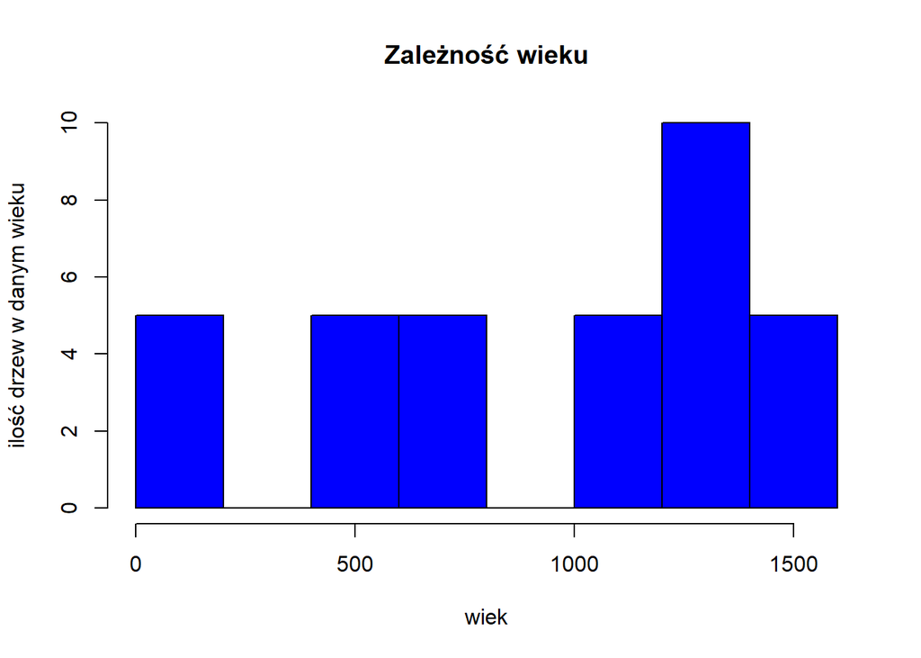

```r
hist(Orange$age,col="blue",main="Zależność wieku",xlab="wiek",ylab="ilość drzew w danym wieku")
```

e) Narysuj wykres pudełkowy z wąsem (boxplot()) dla zmiennych mpg, hp i qsec ze zbioru mtcars.

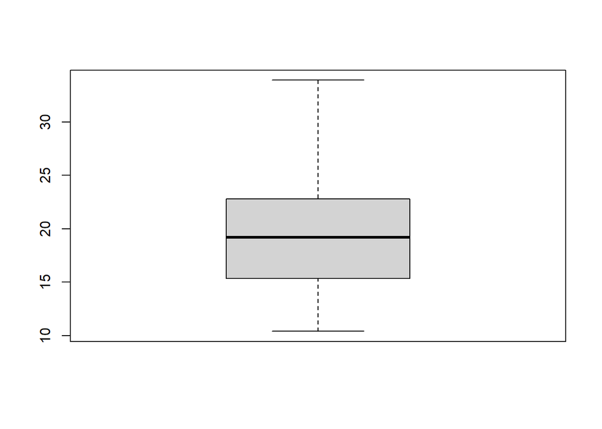

```r
boxplot(mtcars$mpg)
```

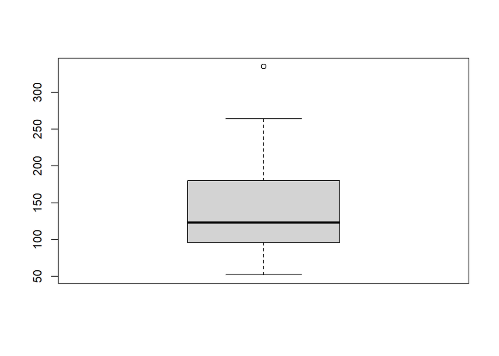

```r
boxplot(mtcars$hp)
```

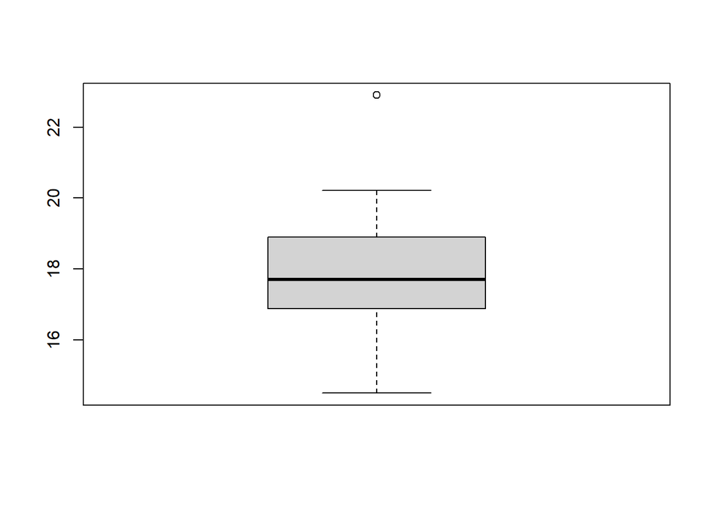

```r
boxplot(mtcars$qsec)
```

*Zadanie 3.*  
Wygeneruj 20 wyników rzutu kostką do gry. Nazwij te zmienna proba. Ile wynosi średnia i odchylenie standardowe?  
Wygeneruj 100 wyników rzutu monetą. Nazwij te zmienna rzut (uwaga: jako 1 możesz oznaczyć orła, jako 0 reszkę). Ile wypadło orłów?  
Wylosuj (bez zwracania) 10 liczb ze zbioru liczb naturalnych od 0 do 100.  
Poznaj funkc- rnorm(), rt() oraz rpois(). Na wymyślonym przez siebie przykładzie, zastosuj jedną z w/w funkcji.

```r
#generowanie rzutów kostką do gry
proba=sample(x=1:6,size=20,replace=TRUE, prob=NULL)
mean(proba) #średnia
```

```
## [1] 3.55
```

```r
sd(proba) #odchylenie standardowe
```

```
## [1] 1.959457
```

```r
#generowanie 100 rzutów monetą
rzut=sample(x=0:1,size=100,replace=TRUE, prob=NULL)#1-orzel,0-reszka
sum(rzut) #określa ile orłóW wypadło
```

```
## [1] 54
```

```r
#losowanie 10 liczb nat z przedzialu 0 do 100
sample(0:100,10,replace=FALSE,prob=NULL)
```

```
##  [1] 61 76 75 53 16 23 71 68  6 40
```

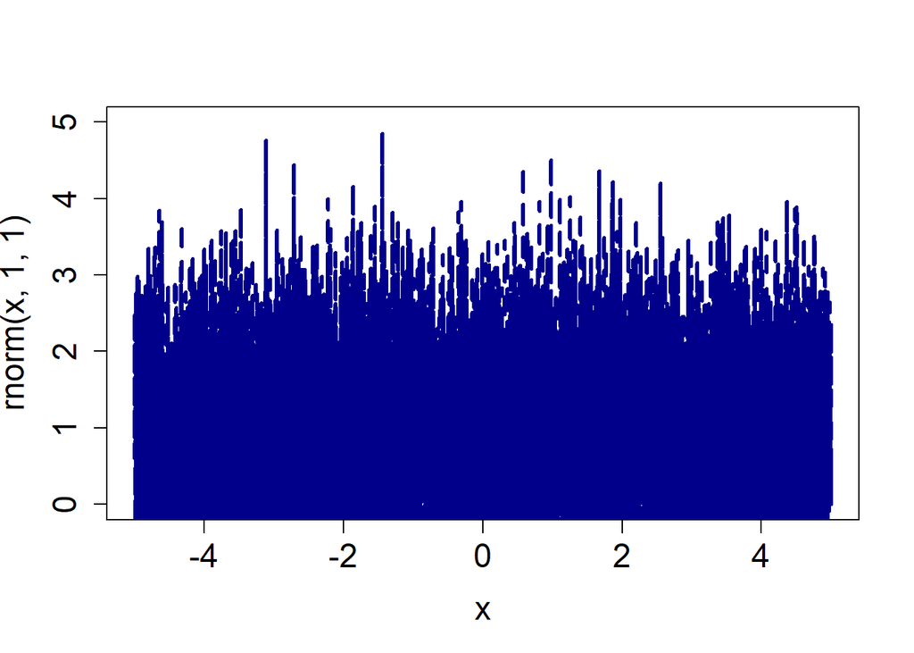

```r
#przykład z funkcją rnorm()
x <- seq(-5,5,by=0.001)
plot(x, rnorm(x, 1,1), type="l", ylim=c(0,5),col="darkblue", lwd=3, cex.axis=1.5, cex.lab=1.5, lty=2)
```

*Zadanie 4.*  
Wśród krajów o PKB niższym od 5000$ (rozważyć dane za rok 1977), wyznaczyć po trzy kraje z Afryki, Europy i Azji, w których spodziewana długość życia jest największa.

```r
#importowanie potrzebnych bibliotek
library(dplyr)
library(tidyr)
library(gapminder)
kraje_1977 <- gapminder %>%
  filter(year == "1977", gdpPercap < 5000, continent != "Americas") %>% #filtrowanie po roku, PKB, usunięciu danych odnośnie krajówobu Ameryk
  group_by(continent) %>% #grupowanie po kontynentach
  top_n(3, lifeExp) #wybór po 3 największych wartościach oczekiwanych długości życia
kraje_1977
```

```
## # A tibble: 9 x 6
## # Groups:   continent [3]
##   country                continent  year lifeExp      pop gdpPercap
##   <fct>                  <fct>     <int>   <dbl>    <int>     <dbl>
## 1 Albania                Europe     1977    68.9  2509048     3533.
## 2 Bosnia and Herzegovina Europe     1977    69.9  4086000     3528.
## 3 Korea, Dem. Rep.       Asia       1977    67.2 16325320     4106.
## 4 Malaysia               Asia       1977    65.3 12845381     3828.
## 5 Mauritius              Africa     1977    64.9   913025     3711.
## 6 Reunion                Africa     1977    67.1   492095     4320.
## 7 Sri Lanka              Asia       1977    65.9 14116836     1349.
## 8 Tunisia                Africa     1977    59.8  6005061     3121.
## 9 Turkey                 Europe     1977    59.5 42404033     4269.
```

*Zadanie 5.*  
Na jednym wykresie liniowym narysować, jak w rozważanych latach zmieniała się oczekiwana długość życia w trzech wybranych przez Ciebie krajach.

Wybrane kraje: Sri Lanka, Albania, Tunisia

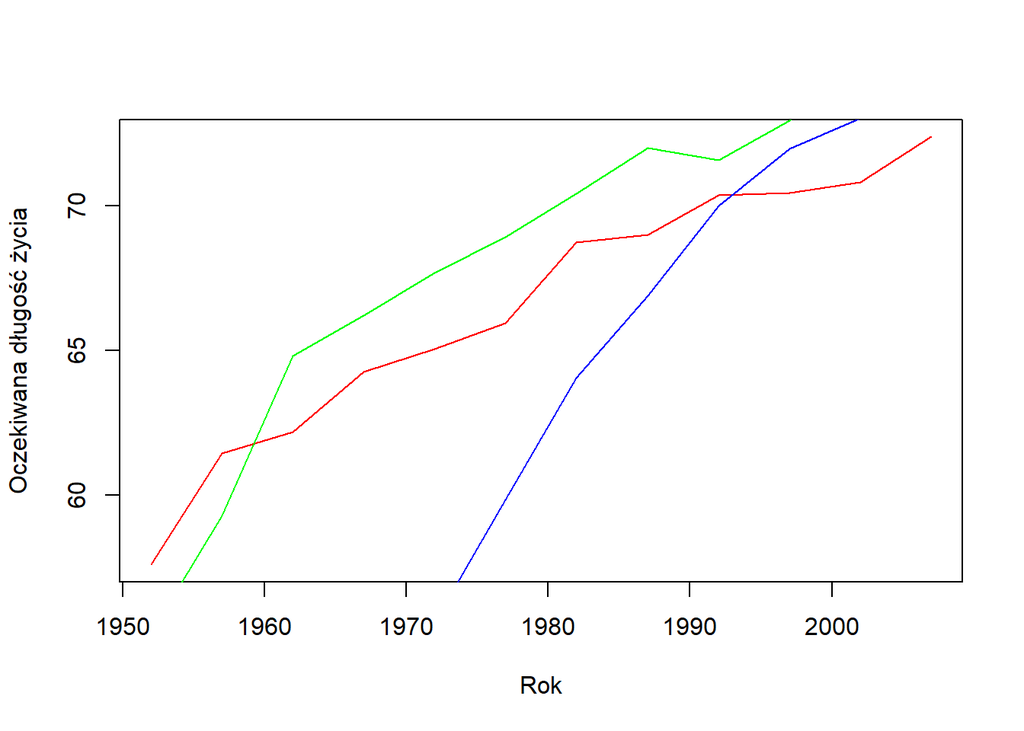

```r
#wyselekcjonowanie potrzebnych kolumn i wyfiltrowanie wybranych krajów
kraj<-gapminder%>%
  select(country, year,lifeExp)%>%
  filter(country %in% c("Sri Lanka", "Albania", "Tunisia"))

#Sri Lanka
kraj1<-kraj%>% filter(country=="Sri Lanka") #filtr po kraju
x1=kraj1$year #zdefiniowanie zmiennych do wykresu
y1=kraj1$lifeExp
plot(x1,y1,type="l",col="red",xlab="Rok",ylab="Oczekiwana długość życia") #tworzenie wykresu i opisanie osi, naniesienie danych

#Albania
kraj2<-kraj%>% filter(country=="Albania")#filtr po kraju
x2=kraj2$year #zdefiniowanie zmiennych do wykresu
y2=kraj2$lifeExp
points(x2,y2,type="l",col="green") #naniesienie kolejnych danych na istniejący już wykres

#Tunisia
kraj3<-kraj%>% filter(country=="Tunisia")#filtr po kraju
x3=kraj3$year #zdefiniowanie zmiennych do wykresu
y3=kraj3$lifeExp
points(x3,y3,type="l",col="blue") #naniesienie kolejnych danych na wykres
```

******************************************************************************************************************  
**ZADANIE 2.**

Na podstawie pliku budzety2005.csv możemy odczytać między innymi następujące informacje o wybranych osobach:  
-miesiąc przeprowadzenia badania,  
-województwo,  
-miejsce zamieszkania,  
-typ zabudowania,  
-wysokość rachunków,  
-dochód na podstawie danych i pochodzący z GUS,  
-główne źródło dochodu,  
-płeć i wiek danej osoby,  
-stan cywilny,  
-wykształcenie,  
-główne zajęcie (student/rolnik/…),  
-liczba miesięcy bez pracy.

```r
#wczytuję plik z budżetami, aby użyć go do dalszej analizy
budzet <- read.csv(file = "budzety2005.csv", sep = ",")
```

Na podstawie zebranych danych chciałabym odpowiedzieć na następujące pytania badawcze:  
**1.** W jakim typie nieruchomości wskaźnik utrzymania 1 m<sup>2</sup> powierzchni (stosunek rachunków do powierzchni mieszkalnej) jest najmniejszy i największy?

```r
#dodawanie wskaźnika rachunku do powierzchni mieszkalnej do ramki danych budzet
budzet<-data.frame(budzet,wskaznik=budzet$bills/budzet$flatsize)
#obliczenie wartosci potrzebnych do wnioskow
#średnie rachunki ogółem
mean(budzet$bills)
```

```
## [1] 321.5774
```

```r
#średnia powierzchni ogółem
mean(budzet$flatsize)
```

```
## [1] 68.48089
```

```r
#drukowanie danych na podstawie krótych poniższe wskaźniki zostały obliczone
aggregate(budzet[,15:16], list(budzet$buildtype), mean)
```

```
##         Group.1 flatsize    bills
## 1 free standing 91.84069 272.9499
## 2    multi-flat 50.87397 356.4142
## 3         other 47.78641 289.7599
## 4  terrace/twin 89.50178 300.5625
```

```r
#obliczenie wskaźników
indeks <- budzet %>%
  group_by(buildtype) %>%
  summarize(id = mean(wskaznik)) %>%
  arrange(id)
indeks[1:4,]
```

```
## # A tibble: 4 x 2
##   buildtype         id
##   <chr>          <dbl>
## 1 free standing   3.38
## 2 terrace/twin    3.72
## 3 other           6.63
## 4 multi-flat    Inf
```

*Wnioski:* *Z obliczeń wynika, że stosunek rachunków do powierzchni mieszkalnej jest największy w bloku mieszkalnym, a najniższy w domu wolnostojącym. Wskazane wartości mogą wynikać z faktu odchyleń od średniej dla ogółu danych. Średnie rachunki dla każdego typu zabudowania odbiegają maksymalnie 15,12% od średnich rachunków ogólnie, zaś średnie odchylenie wynosi 10,6%. W przypadku powierzchni najmniejsze z odchyleń wynosi 25,7%, a średnie odchylenie osiąga poziom 30,18%.*

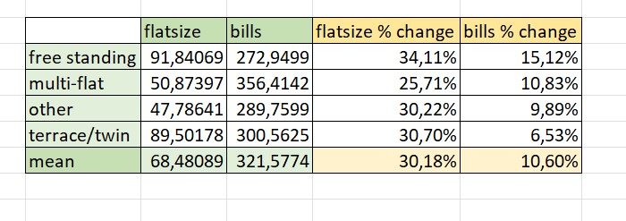

**2.** W jakim województwie ludzie osiągają najwyższe dochody? Czy najwyższe dochody są też skorelowane z największym odsetkiem osób z wyższym wykształceniem?  
Czy w województwie z najniższymi dochodami jest najmniejszy odsetek osób z wyższym wykształceniem?

```r
#badanie w których wojewodztwach są najwyzsze i najnizsze dochody
dochod_wg_woj <- budzet %>%
  group_by(wojregion) %>%
  summarize(dochod = mean(totincGUS)) %>%
  arrange(desc(dochod))
dochod_wg_woj
```

```
## # A tibble: 16 x 2
##    wojregion           dochod
##    <chr>                <dbl>
##  1 Mazowieckie          2755.
##  2 Opolskie             2400.
##  3 Wielkopolskie        2374.
##  4 Pomorskie            2356.
##  5 Malopolskie          2323.
##  6 Warminsko-mazurskie  2308.
##  7 Slaskie              2238.
##  8 Lodzkie              2212.
##  9 Lubelskie            2188.
## 10 Zachodniopomorskie   2174.
## 11 Dolnoslaskie         2087.
## 12 Podkarpackie         2082.
## 13 Podlaskie            2032.
## 14 Kujawsko-pomorskie   2016.
## 15 Swietokrzyskie       1993.
## 16 Lubuskie             1779.
```

*Najwyższe dochody osiągają ludzie mieszkający w województwie mazowieckim, a najniższe osoby z województwa lubuskiego.*

```r
#obliczenie odsetku osób z wyższym wykształceniem w każdym z województw:

#obliczenie liczby osób (biorących udział w badaniu) z wyższym wykształceniem z podziałem na wojewodztwa
osobywyksz <- budzet %>%
  filter(educ=="university")%>%
  group_by(wojregion) %>%
  count(educ)

#obliczenie liczby osób z województw
liczbawoj<-budzet %>%
  group_by(wojregion)%>%
  count(wojregion)

osobywyksz<-data.frame(osobywyksz,liczbawoj[,2])
osobywyksz<-data.frame(osobywyksz,odsetek=osobywyksz[,3]/osobywyksz[,4])

library(formattable)
odset<-osobywyksz%>%
  mutate(odsetek=percent(round(odsetek,3)))%>%
  arrange(desc(odsetek))
odset
```

```
##              wojregion       educ   n  n.1 odsetek
## 1          Mazowieckie university 609 4187  14.50%
## 2          Malopolskie university 294 2428  12.10%
## 3            Pomorskie university 192 1673  11.50%
## 4             Lubuskie university  79  705  11.20%
## 5            Podlaskie university  96  888  10.80%
## 6        Wielkopolskie university 258 2400  10.80%
## 7   Zachodniopomorskie university 147 1365  10.80%
## 8             Opolskie university  92  869  10.60%
## 9              Lodzkie university 244 2348  10.40%
## 10             Slaskie university 391 3773  10.40%
## 11        Podkarpackie university 158 1560  10.10%
## 12      Swietokrzyskie university  92  929   9.90%
## 13        Dolnoslaskie university 241 2515   9.60%
## 14 Warminsko-mazurskie university 107 1121   9.50%
## 15           Lubelskie university 147 1724   8.50%
## 16  Kujawsko-pomorskie university 122 1518   8.00%
```

```r
x=odset$odsetek
y=dochod_wg_woj$dochod
#korelacje
pearson<-cor(x,y,method="pearson")
percent(pearson)
```

```
## [1] 97.72%
```

```r
spearman<-cor(x,y,method="spearman")
percent(spearman)
```

```
## [1] 99.63%
```

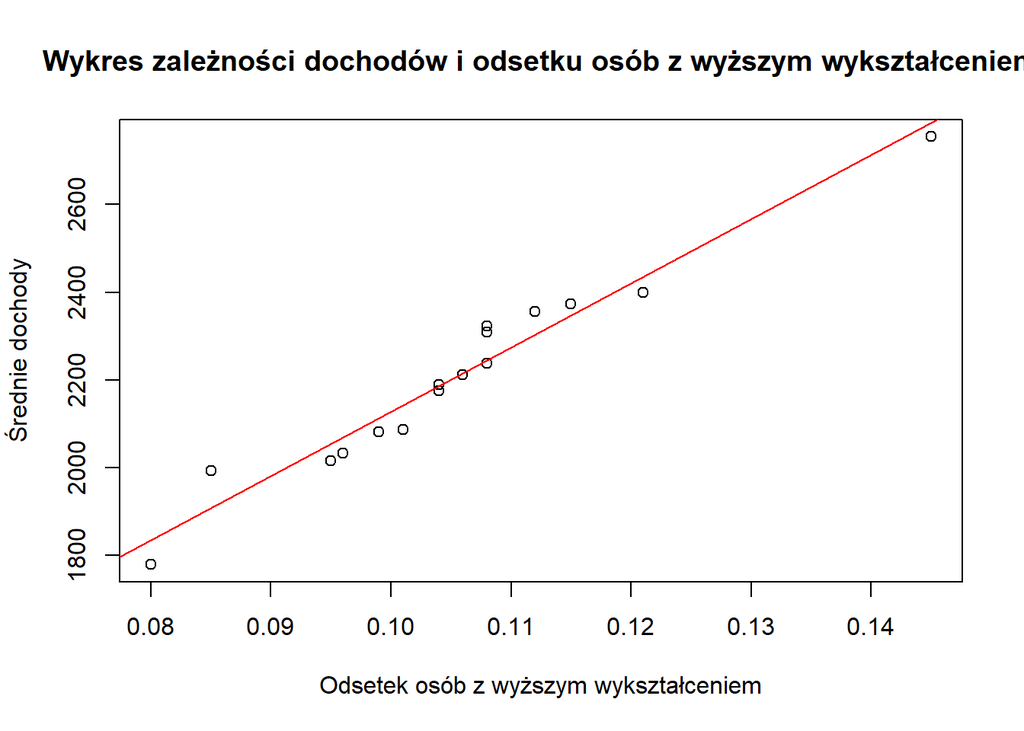

```r
#wykres
plot(x,y,main = "Wykres zależności dochodów i odsetku osób z wyższym wykształceniem",
     xlab = "Odsetek osób z wyższym wykształceniem",
     ylab = "Średnie dochody")
abline(lm(y ~ x), col = "red") #dopasowanie lini
```

**3.** Czy bycie w związku małżenskim wpływa na wysokość dochodu?

```r
a<-aggregate(budzet[,21], list(budzet$sex), mean)
a
```

```
##   Group.1        x
## 1 female  1235.161
## 2    male 1241.919
```

```r
k<-a[1,2] #kobiety
m<-a[2,2] #mężczyźni
roznica<-(m-k)/k
percent(roznica)
```

```
## [1] 0.55%
```

Dochody kobiet i mężczyzn są porównywalne z niewielką przewagą mężczyzn - dochody mężczyzn są o 0.55% wyższe niż dochody kobiet.

```r
b<-aggregate(budzet[,21], list(budzet$sex,budzet$married), mean)
b
```

```
##   Group.1 Group.2        x
## 1 female        0 1160.648
## 2    male       0 1146.126
## 3 female        1 1328.286
## 4    male       1 1328.352
```

```r
kn<-b[1,3] #dochody kobiet niezamężnych
km<-b[3,3] #dochody kobiey zamężnych
mn<-b[2,3] #dochody mężczyzn nieżonatych
mm<-b[4,3] #dochody mężczyzn żonatych
roznicak<-(km-kn)/kn #o tyle wieksze są dochody kobiet zameznych
roznicam<-(mm-mn)/mn #o tyle większe są dochody mezczyzn zonatych
percent(roznicak)
```

```
## [1] 14.44%
```

```r
percent(roznicam)
```

```
## [1] 15.90%
```

Niezależnie od płci dochody osób będących w związkach małżeńskich są większe niż osób niebędących w związkach. Dochody kobiet zamężnych są o 14,44% większe niż niezamężnych, a mężczyzn żonatych o 15,9% większe niż nieżonatych.

```r
c<-aggregate(budzet[,21], list(budzet$married),mean)
c
```

```
##   Group.1        x
## 1       0 1154.559
## 2       1 1328.319
```

```r
married<-c[2,2]
notmarried<-c[1,2]
roznica<-(married-notmarried)/notmarried
percent(roznica)
```

```
## [1] 15.05%
```

Osoby w związkach małżeńskich mają dochody o 15,05% wyższe niż osoby niebędące w związkach małżeńskich.

**4.** Jakie źródło dochodu przeważa u osób mieszkających na wsiach i w miasteczkach do 20 tys mieszkańców z podziałem na grupy wiekowe:18-30, 31-59, 60+?

```r
#grupa 18-30
grupa18_30<- budzet %>%
  filter(townsize %in% c("villages", "town up to 19,999"),age<=30,age>=18)%>%
rename(zrodlo_dochodu=mainincHH)%>%
  count(zrodlo_dochodu, sort=TRUE)

a<-sum(grupa18_30[,2])

grupa18_30<-data.frame(grupa18_30,procent=percent(grupa18_30[,2]/a))
grupa18_30
```

```
##                                             zrodlo_dochodu   n procent
## 1                                         employee, manual 983  41.34%
## 2                                     employee, non-manual 421  17.70%
## 3                                                   farmer 269  11.31%
## 4                                         disability pens. 203   8.54%
## 5                                         retirement pens. 198   8.33%
## 6                                        nonfarm selfempl. 153   6.43%
## 7                                     unemployment benefit  66   2.78%
## 8                                  other social assistance  52   2.19%
## 9  gifts, alimony payments from other people, other income  30   1.26%
## 10                                                   other   2   0.08%
## 11                        from rent of house(flat), garage   1   0.04%
```

```r
#grupa 31-59
grupa31_59<- budzet %>%
  filter(townsize %in% c("villages", "town up to 19,999"),age<=59,age>=31)%>%
  rename(zrodlo_dochodu=mainincHH)%>%
  count(zrodlo_dochodu, sort=TRUE)

a<-sum(grupa31_59[,2])

grupa31_59<-data.frame(grupa31_59,procent=percent(grupa31_59[,2]/a))
grupa31_59
```

```
##                                             zrodlo_dochodu    n procent
## 1                                         employee, manual 1884  31.46%
## 2                                     employee, non-manual 1033  17.25%
## 3                                         retirement pens.  787  13.14%
## 4                                         disability pens.  742  12.39%
## 5                                                   farmer  716  11.96%
## 6                                        nonfarm selfempl.  415   6.93%
## 7                                     unemployment benefit  214   3.57%
## 8                                  other social assistance  117   1.95%
## 9  gifts, alimony payments from other people, other income   53   0.88%
## 10                                                   other   22   0.37%
## 11                        from rent of house(flat), garage    6   0.10%
```

```r
#grupa 60+
grupa60<- budzet %>%
  filter(townsize %in% c("villages", "town up to 19,999"),age>=60)%>%
  rename(zrodlo_dochodu=mainincHH)%>%
  count(zrodlo_dochodu, sort=TRUE)

a<-sum(grupa60[,2])

grupa60<-data.frame(grupa60,procent=percent(grupa60[,2]/a))
grupa60
```

```
##                                             zrodlo_dochodu    n procent
## 1                                         retirement pens. 2324  69.60%
## 2                                         disability pens.  564  16.89%
## 3                                                   farmer  145   4.34%
## 4                                         employee, manual  143   4.28%
## 5                                     employee, non-manual   93   2.79%
## 6                                     unemployment benefit   24   0.72%
## 7                                        nonfarm selfempl.   21   0.63%
## 8                                  other social assistance   15   0.45%
## 9  gifts, alimony payments from other people, other income    8   0.24%
## 10                        from rent of house(flat), garage    2   0.06%
```

*Wnioski:* *W grupach wiekowych 18-30 oraz 31-59 jako główne źrodło dochodu przeważa praca fizyczna. Jednak w grupie 31-59 źródła dochodu są bardziej zróżnicowane na pracę fizyczną i umysłową, a także emerytury, renty i rolnictwo. W grupie osób 60+ znacznie przeważa dochód ze świadczeń emerytalnych.*